# Data Science Capstone Milestone Report

Finbark

2 April 2019

# Introduction

This milestone report shows the results of exploratory analysis done on the initial data set. It then moves on to discuss the forthcoming predictive model.

# Getting the data

This section outlines how the data was obtained and sampled.

### Load the initial data

The data is downloaded and unzipped to the local directory. But only if it hasn’t already been downloaded

```r
if (!file.exists("./data.zip")) {
    URL <- "http://d396qusza40orc.cloudfront.net/dsscapstone/dataset/Coursera-SwiftKey.zip"
    download.file(URL, destfile = "data.zip", method = "curl")
    unzip("data.zip")
}
```

### Read and sample data

To make things faster, the data is loaded but only a sample is taken

```r
start <- function() {
    files <- list.files(path = './final/en_US/', pattern = "*.txt")
    files <- lapply(files, function(x) paste('./final/en_US/', x, sep = ""))
    dataSample <- unlist(lapply(files, function(x) loadAndSampleData(x, 20000)))
}

loadAndSampleData <- function(data, sample_size) {
    sampleData <- readLines(data, warn = FALSE, encoding = "UTF-8", skipNul = TRUE)
    sampleData <- selectiveSample(sampleData, sample_size)
}

## Used to handle when the desired sample size is greater than the data set.
selectiveSample <- function(data, sample_size) {
    if (length(data) < sample_size) {
        data
    }
    else {
        sample(data, sample_size)
    }
}

data_sample <- start()
```

# Initial exploration

This section shows the initial exploration on the the three main data sets and then the sampled data set.

### Blog data set

```
##      Source Total.lines Total.words Total.characters
## 1 Blog data      899288    37865888        208361438
```

### News data set

```
##      Source Total.lines Total.words Total.characters
## 1 News data       77259     2665742         15683765
```

### Twitter data set

```
##         Source Total.lines Total.words Total.characters
## 1 Twitter data     2360148    30578891        162384825
```

### Sample data set

[output not shown]

# Creating a clean corpus of text

The tm package is now used on the sample data to convert it into an appropriate format for ngrams. The data is also cleaned.To avoid repetition, the results are saved so they can be loaded again later.

```r
start <- function() {
    profanity <- readLines("./profanityFilter/profanityFilter.txt")
    tokenizedData <- createTokenizedData(data_sample)
    cleanTokenizedData <- cleanTokenizedData(tokenizedData, profanity)
    documentMatrix <- TermDocumentMatrix(cleanTokenizedData)
    cleanTokenizedData
}

createTokenizedData <- function(data) {
    Corpus(VectorSource(data))
}

cleanTokenizedData <- function(data, filter) {
    removeURL <- function(x) gsub("http[[:alnum:]]*", "", x)
    cleanData <- tm_map(data, content_transformer(removeURL))
    cleanData <- tm_map(cleanData, content_transformer(tolower))
    cleanData <- tm_map(cleanData, content_transformer(removePunctuation))
    cleanData <- tm_map(cleanData, content_transformer(removeNumbers))
    cleanData <- tm_map(cleanData, stripWhitespace)
    cleanData <- tm_map(cleanData, removeWords, stopwords("english"))
    cleanData <- tm_map(cleanData, removeWords, filter)
}

saveCorpusandMatrix <- function(corpus, matrix) {
    saveRDS(corpus, file = "./Corpus.RData")
}

corpus <- start()
```

# Creating Ngrams

Before we do the last bit of analysis, we need to create sets of ngrams from the corpus. They are saved for ease of access later.

```r
start <- function() {
    bigram <- ngramTokenizer(corpus, 2)
    saveRDS(bigram, file = "./ProcessData/bigram.RDS")
    rm(bigram)
    trigram <- ngramTokenizer(corpus, 3)
    saveRDS(trigram, file = "./ProcessData/trigram.RDS")
    rm(trigram)
    quadgran <- ngramTokenizer(corpus, 4)
    saveRDS(quadgran, file = "./ProcessData/quadgram.RDS")
}

ngramTokenizer <- function(corpus, ngramCount) {
    ngram <- NGramTokenizer(corpus,
                            Weka_control(min = ngramCount, max = ngramCount, delimiters = " \\r\\n\\t.,;:\"()?!"))
    ngram <- data.frame(table(ngram))
    ngram <- ngram[order(ngram$Freq, decreasing = TRUE),][1:10,]
    colnames(ngram) <- c("String","Count")
    ngram

}

start()
```

# Ngram exploration

We now move to explore the three types of Ngrams, and show the 10 most frequent terms in each file.

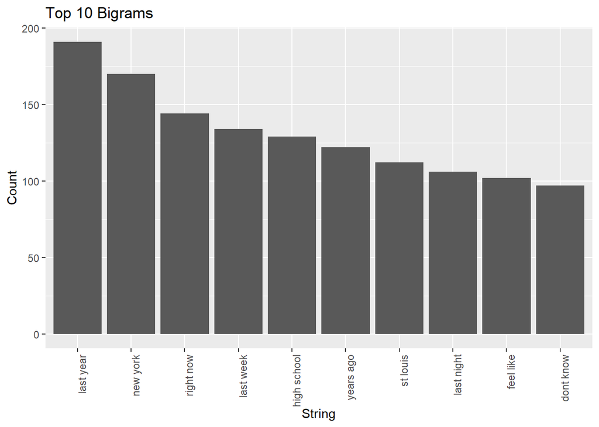

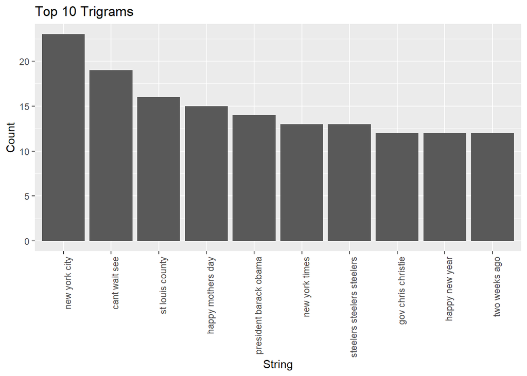

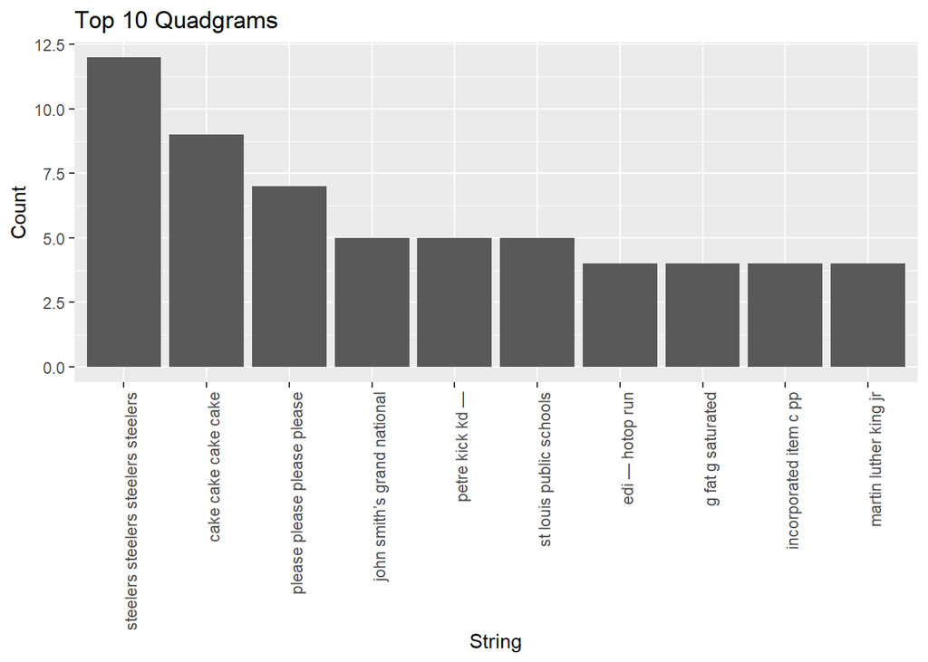

# Findings

From the initial exploration, we can see that there are some commonalities between the three sets of ngrams; for example, ‘new york’ and ‘new york city’. But for the most part, the three sets are different.

# Next steps

The main next step is to develop a prediction algorithm from the data ngram data sets. The algorithm will search the quadgrams first, then failing that, search the trigrams, and then bigrams. If there is a match with multiple ngrams withing a given dataset, the most common one will be selected.

One essential step to doing this will be to restructure the data so instead of a full string in a column, each word in the ngram is its own column. This will be achieved using the str_split_fixed function from the stringr package.